# RNASeq-Differential-Expression of SARS-CoV-2

Nunez Gonzalez, Laura

2026-02-11

# Libraries

```r
# ==============================================================================
# 1. DATA ACQUISITION AND GENOMIC ANNOTATION
# ==============================================================================

# Genome annotation from Homo sapiens
library(org.Hs.eg.db)
library(EnsDb.Hsapiens.v86)

# Infrastructure for representing and manipulating data from GEO and genomic intervals
library(SummarizedExperiment)
library(GenomicRanges)

# ==============================================================================
# 2. RNA-seq DATA PREPROCESSING AND READ COUNT NORMALIZATION
# ==============================================================================

# General data manipulation
library(tidyverse)
library(here)
library(dplyr)
library (knitr)
library(kableExtra)

#TMM and log2 normalization
library(edgeR)

# ==============================================================================
# 3. EXPLORATORY DATA ANALYSIS
# ==============================================================================

# Visualization
library(ggplot2)       # Basic visualization tool
library(ggrepel)       # Modification of text over the graphs
library(RColorBrewer)  # Color palettes
library(gridExtra)     # Arrange grid in plots
library(pheatmap)      # Creation of high-quality heat maps
library(dendextend)    # Color palettes in dendograms
library (patchwork)    # Combination of different graphics
library(ComplexUpset)  # Creation of graphics for multiple intersections (UpSet plots)

# ==============================================================================
# 4. DIFFERENTIAL GENE EXPRESSION ANALYSIS: FUNCTIONAL ENRICHMENT & INTERPRETATION
# ==============================================================================

# Statistical frameworks for Differential Expression Genes (DEGs) analysis
library(DESeq2)
library(EnhancedVolcano) # Creation of high-quality volcano plots of DEGs
library(BiocParallel)
library(clusterProfiler) #Functional enrichment analysis

# Note: Detailed library information is documented in the session_info.txt.
```

# 1. Introduction

This study, published in 2021 following the **SARS-CoV-2 pandemic (McClain et al., 2021)**, explores the activation of biological processes and molecular markers in **peripheral blood samples from infected patients**. These findings are further compared against other respiratory conditions, **including bacterial pneumonia, influenza virus infection, and healthy controls**.

The analytical approach employed is **mRNA transcriptomics using an universal library preparation**. Sequencing was performed on the Illumina® NovaSeq 6000 platform. Stringent quality control filters were applied, including a minimum read length of 100 base pairs and a depth of at least 50 million reads per patient sample.

Collectively, this research provides an exhaustive understanding of the biological—primarily immunological—response associated with each respiratory pathology, enabling a detailed comparative analysis of their shared and distinct molecular signatures.

# 2. Objectives

1. Data Processing & Replication: Using the raw data deposited in GEO (GSE161731), this project performs a complete end-to-end processing workflow. The analysis is conducted starting from raw counts, replicating the original investigators’ rigorous approach to ensure data integrity.
2. Structured Transcriptomic Pipeline: The project follows a systematic and ordered pipeline for analyzing transcriptomic data. This workflow transitions from raw data preprocessing and normalization to a final functional analysis, identifying the dysregulated biological pathways and molecular signatures associated with each respiratory pathology.

# 3. Methodology

The transcriptomic **workflow was implemented in R (v4.x) using the Bioconductor framework**. Information of packages and versions is available in Session_info.txt file. Raw sequencing counts and clinical metadata were retrieved from the NCBI **Gene Expression Omnibus (GEO) under accession number GSE161731** and integrated into a **SummarizedExperiment object for downstream analysis**. To ensure accurate feature attribution, **genomic coordinates** were mapped to the transcripts, followed by a rigorous data-wrangling process to filter out non-informative variables and standardize gene nomenclature.

Following quality control, **Differential Expression Analysis (DEA) was conducted using the DESeq2 package**, which employs empirical Bayes shrinkage to estimate dispersion and fold-change. Finally, to characterize the biological significance of the results, we performed Functional Enrichment Analysis. **Overrepresented Gene Ontology (GO)** terms were identified to elucidate the molecular pathways and immunological signatures associated with COVID-19 and bacterial pneumonia relative to healthy controls.

# 4. Results

## 4.1 Data acquisition

Data acquisition is implemented from local archives (downloaded from GEO):

```r
data_path <- here("GSE161731")

#Expression matrix
counts <- read.csv(here("GSE161731", "GSE161731_counts.csv.gz"),
                   row.names = 1, check.names = FALSE) #with row.name = 1 we associate all the row data to the gene (which is detailed in the first column)

#Metadata
metadata <- read.csv(here("GSE161731", "GSE161731_key.csv.gz"),
                     header = TRUE, row.names = 1, check.names = FALSE) #same argument, but in this case we are associating sample id (patient) with the remaining data

#Specific selection of the intersection about colnames from counts and rownames from metadata
common_samples <- intersect(colnames(counts), rownames(metadata))
counts_clean <- as.matrix(counts[, common_samples]) #sorted based on common_samples
metadata_clean <- metadata[common_samples, ]
```

Addition of chromosomic location:

```r
# Removal of different gene versions
rownames(counts_clean) <- gsub("\\..*$", "", rownames(counts_clean))

#Annotation calling
edb <- EnsDb.Hsapiens.v86
genes_coords <- genes(edb)

common_genes <- intersect(rownames(counts_clean), names(genes_coords))

counts_final <- counts_clean[common_genes, ]
coords_final <- genes_coords[common_genes]
metadata_final <- metadata_clean
```

Now, we can create the object: **summarizedExperiment**

```r
se <- SummarizedExperiment(
  assays = list(counts = counts_final),
  colData = DataFrame(metadata_final),
  rowRanges = coords_final
)

#We include metadata information (empty by defect)
metadata(se) <- list(
  GEO_accession = "GSE161731",
  organism = "Homo sapiens",
  assay_type = "RNA-seq"
)

#Definitive object: summarizedExperiment
se
```

```
## class: RangedSummarizedExperiment
## dim: 57602 195
## metadata(3): GEO_accession organism assay_type
## assays(1): counts
## rownames(57602): ENSG00000223972 ENSG00000227232 ... ENSG00000277475
##   ENSG00000268674
## rowData names(6): gene_id gene_name ... symbol entrezid
## colnames(195): 94189 DU09-03S0000604 ... 105847 105848
## colData names(8): subject_id age ... hospitalized batch
```

## 4.2 RNA-seq Data Preprocessing and Read Count Normalization

### 4.2.1 Data preprocessing

```r
# DUPLICATES EXTRACTION AND REMOVAL
# We will maintain only the first entry of each duplicated sample
metadata_raw <- as.data.frame(colData(se)) #We convert the colData in a normal dataframe for easy manipulation
metadata_unique <- metadata_raw[!duplicated(rownames(metadata_raw)), ]
rownames(metadata_unique) <- rownames(metadata_raw)[!duplicated(rownames(metadata_raw))]

# Selection of specific cohorts
target_cohorts <- c("COVID-19", "Bacterial", "healthy")
metadata_cohorts <- metadata_unique[metadata_unique$cohort %in% target_cohorts, ]

# Standarization of special characters
colnames(metadata_cohorts) <- gsub("[[:space:]\\-\\\\/]", "_", colnames(metadata_cohorts)) #Standarized colnames, withouth hyphens, spaces and slashes (replaced by underscore)

#Now, we will clean the data inside the columns (in the character columns):
metadata_cohorts <- metadata_cohorts %>%
  mutate(across(where(is.character), ~ gsub("\\s|\\-|/", "_", .x)))

#We eliminate all the characters in age column
metadata_cohorts$age <- as.numeric(gsub("[^0-9]", "", metadata_cohorts$age))

#Get the summarizedExperiment with all these changes included
keep_samples <- rownames(metadata_cohorts)
se_clean <- se[, keep_samples]
colData(se_clean) <- DataFrame(metadata_cohorts)

cohort_counts <- table(colData(se_clean)$cohort)
tabla_df <- as.data.frame(cohort_counts)
colnames(tabla_df) <- c("Clinical Cohort", "Number of Samples")
kable(tabla_df, caption = "Table 1: Sample distribution across clinical cohorts.")
```

Table 1: Sample distribution across clinical cohorts.

| Clinical Cohort | Number of Samples |
| --- | --- |
| Bacterial | 23 |
| COVID_19 | 77 |
| healthy | 19 |

Now, we have 3 clean cohort which contains 19 healthy individuals, 23 who suffered from bacterial pneumonia and 77 patients from COVID-19.

Once the data has been correctly preprocessed, we must **remove all the genes with low expression (probable biological noise)**.

```r
# Removal of genes with <10 total counts
keep <- rowSums(assay(se_clean, "counts")) >= 10

#Removal of these genes in which the 90% of the values correspond to zero
keep <- keep & rowSums(assay(se_clean, "counts") == 0) <= 0.9 * ncol(se_clean)

se_filtered <- se_clean[keep, ] #We maintain the aforementioned files (TRUE under keep variable and all the columns)
print(paste("Genes after data cleaning processing:", sum(keep), "Final genes for the study:", nrow(se_filtered)))
```

```
## [1] "Genes after data cleaning processing: 28258 Final genes for the study: 28258"
```

At the beginning we had near 60K genes. Now, we will work only with near to 30K (**50% of the genes are noise to the study**).

### 4.2.2 TMM and log Normalization

Following author’s criteria, we will employ TMM (Trimmed Mean of M-values) normalization (Robinson & Oshlack, 2010) . With this methodology, the most central values will be averaging and the extreme values will be dropped out. Normalized counts were then transformed to log<sub>2</sub>CPM with pseudo-count (prior.count=1) with this criteria:

**TMM normalization**

1. **For each sample vs. reference** (calculated by edgeR):
   - Compute $log_2$(count$_{\text{sample}}$/count$_{\text{reference}}$) **per gene**
   - **Trim** extreme values (75% outliers removed)
   - Average the central 25% → **TMM factor**
2. **Normalize**: $counts_{\text{TMM}} = raw\_counts / TMM\_factor$
3. **log2CPM**: $logCPM = log_2\left(\frac{counts_{\text{TMM}} \times 10^6}{library\_size} + 1\right)$

This double-normalization corrects both **composition bias** (TMM) and **library size** (CPM), stabilizing variance for downstream PCA/clustering.

TMM normalization: For each sample vs. reference sample (edgeR) - TMM factor considerate the number of reads of each gene - Calculate $log2(raw counts/TMM factor])$ for each single sample - Remove extreme values: atypical data - Average 25% of central values

$normalized_counts = raw counts / TMM factor$

$logCPM = log2( (normalized_counts * 1e6) / 1e6 + prior.count )$

```r
# 1. Extraction of raw data (counts) to create a new object: DEGList
counts_matrix <- assay(se_filtered, "counts")
dge <- DGEList(counts = counts_matrix)
dge <- calcNormFactors(dge, method = "TMM") #TMM is already included in this package and ready to use

# Logarithmic transformation
logCPM <- cpm(dge, log = TRUE, prior.count = 1)

# We save this information as new assay
assay(se_filtered, "TMM_log2") <- logCPM
```

## 4.3 Exploratory data analysis (EDA)

### 4.3.1 Visualization tools

#### 4.3.1.1 PCA (Principal Component Analysis)

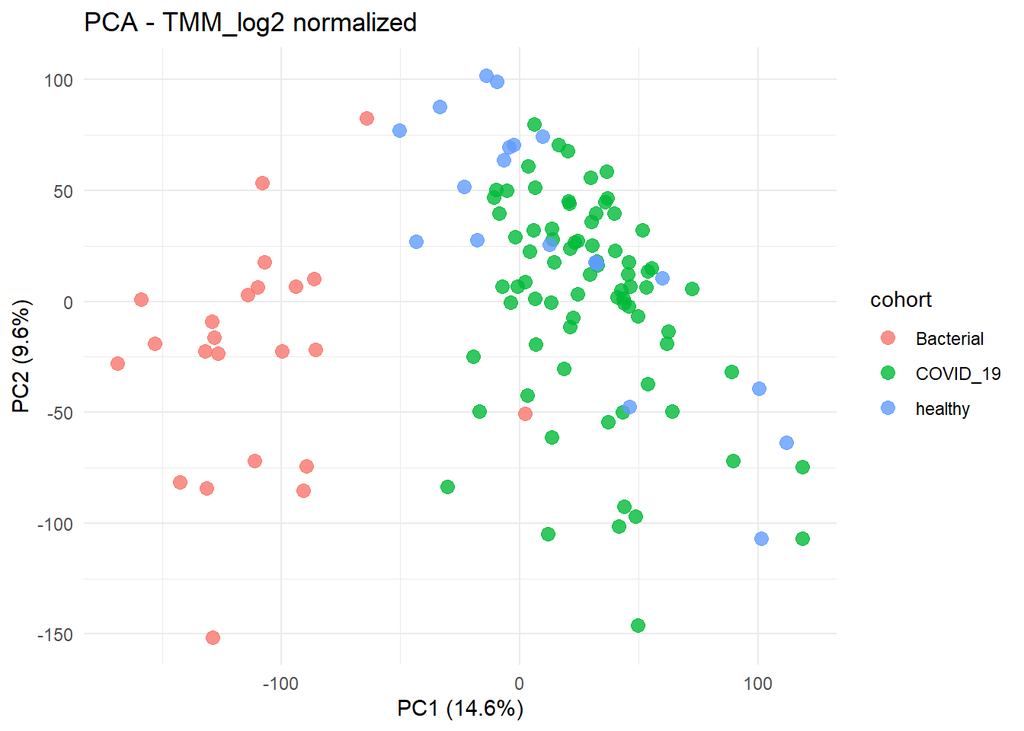

```r
# Data extraction from TMM_log2
plot_data <- assay(se_filtered, "TMM_log2")
pca_res <- prcomp(t(plot_data), scale. = TRUE)

# Data frame for ggplot
pca_df <- data.frame(
  PC1 = pca_res$x[,1],
  PC2 = pca_res$x[,2],
  cohort = colData(se_filtered)$cohort,
  batch = colData(se_filtered)$batch,
  gender = colData(se_filtered)$gender,
  sample = colnames(se_filtered)
)

# PCA
ggplot(pca_df, aes(PC1, PC2, color = cohort)) +
  geom_point(size = 3, alpha = 0.8) +
  labs(title = "PCA - TMM_log2 normalized",
       x = paste0("PC1 (", round(summary(pca_res)$importance[2,1]*100,1), "%)"),
       y = paste0("PC2 (", round(summary(pca_res)$importance[2,2]*100,1), "%)")) +
  theme_minimal()
```

Visual analysis of the gene expression profiles reveals a **clear segregation of the bacterial infection samples**. In contrast, considerable **overlap is observed between the transcripts of COVID-19 patients and healthy controls**.

#### 4.3.1.2 MDS (Multidimensional Scaling)

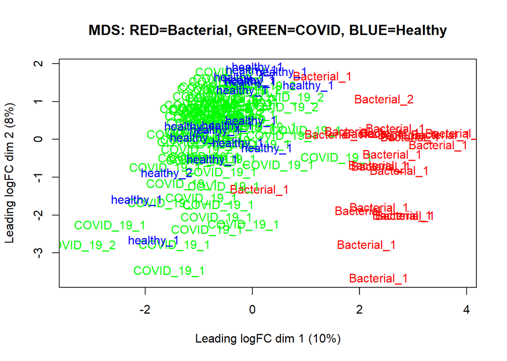

```r
# MDS
palette <- c("Bacterial" = "red", "COVID_19" = "green", "healthy" = "blue")
cohort_factor <- factor(colData(se_filtered)$cohort)
palette_mds <- palette[cohort_factor]

plotMDS(dge,
        col = palette_mds,
        labels = paste(colData(se_filtered)$cohort,
                      colData(se_filtered)$batch, sep="_"),
        main = "MDS: RED=Bacterial, GREEN=COVID, BLUE=Healthy")
```

Both analyses (PCA and MDS) demonstrate a **consistent sample segregation**, confirming the robustness of the overall clustering pattern.

#### 4.3.1.3 Heatmap

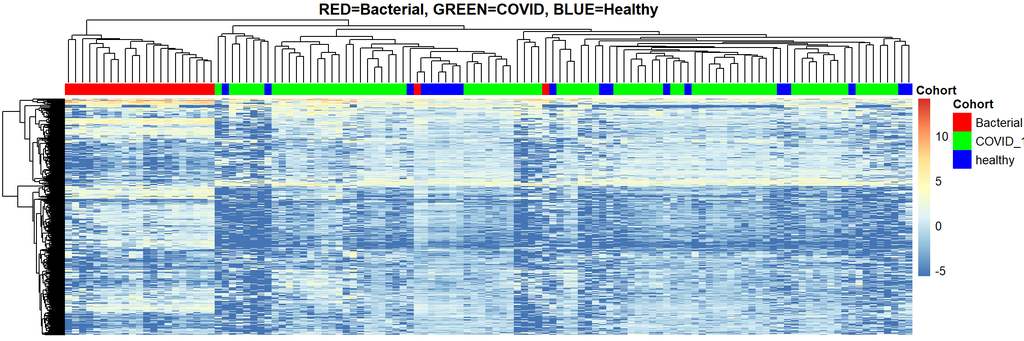

```r
tmm_data <- assay(se_filtered, "TMM_log2")
tmm_clean <- tmm_data; tmm_clean[is.infinite(tmm_data) | is.na(tmm_data)] <- 0

# Top 1000 genes variables
rv <- apply(tmm_clean, 1, var, na.rm = TRUE); rv[is.na(rv)] <- 0
top_genes <- order(rv, decreasing = TRUE)[1:1000]

annotation_col <- data.frame(Cohort = colData(se_filtered)$cohort)
rownames(annotation_col) <- colnames(tmm_clean)
annotation_colors <- list(Cohort = c("Bacterial" = "red", "COVID_19" = "green", "healthy" = "blue"))
pheatmap(tmm_clean[top_genes, ],
         annotation_col = annotation_col,
         annotation_colors = annotation_colors,
         show_rownames = FALSE,
         show_colnames = FALSE,
         main = "RED=Bacterial, GREEN=COVID, BLUE=Healthy")
```

The hierarchical clustering dendrogram reveals **distinct separation of the Bacterial cohort** (red annotation bar), while **COVID-19 and healthy samples show partial overlap**. This confirms previous visualization tools, such as PCA.

### 4.3.2 Atypical data identification

We select **Ward method to calculate minimum variance inside each cluster** (version D2).

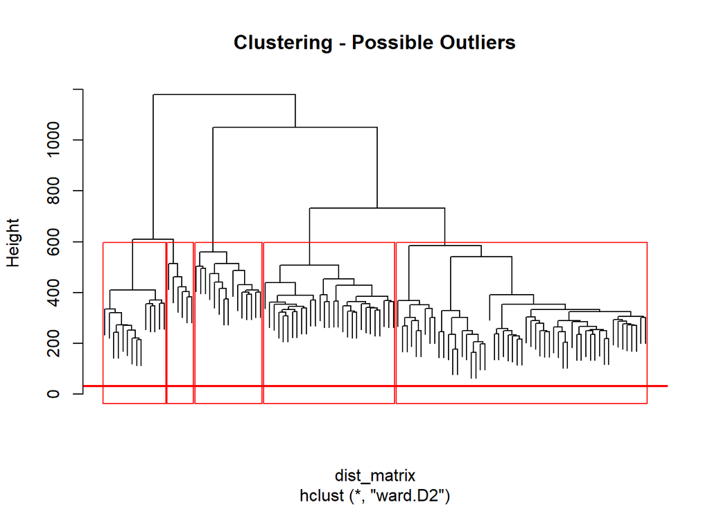

```r
# Distance calculation
dist_matrix <- dist(t(tmm_clean))
hclust_res <- hclust(dist_matrix, method = "ward.D2")

# Plot to visualize outliers
plot(hclust_res, labels = FALSE, main = "Clustering - Possible Outliers")
abline(h = 30, col = "red", lwd = 2)  # Cutoff
rect.hclust(hclust_res, k = 5, border = "red")
```

With this method, 5 different clusters were created. Now, we must see the possible correspondence of these clusters with biological cohorts.

```r
# We define the previous clusters
clusters_5 <- cutree(hclust_res, k = 5)

# We extract cohort data from summarizedExperiment
comparison_df <- data.frame(
  Sample = names(clusters_5),
  Cluster = as.factor(clusters_5),
  Cohort = colData(se_filtered)$cohort
)

# Table
contingency_table <- table(Cluster = comparison_df$Cluster, Cohort = comparison_df$Cohort)
```

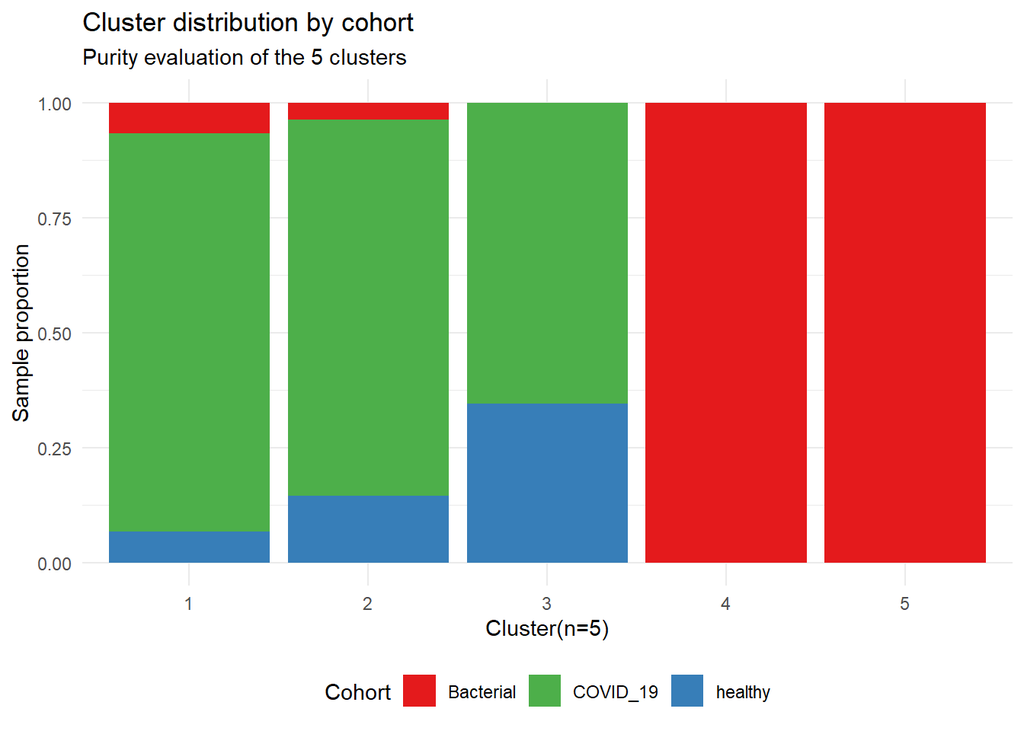

```r
ggplot(comparison_df, aes(x = Cluster, fill = Cohort)) +
  geom_bar(position = "fill") + # "fill" muestra proporciones (0 a 1)
  theme_minimal() +
  scale_fill_manual(values = c("Bacterial" = "#E41A1C", "COVID_19" = "#4DAF4A", "healthy" = "#377EB8")) +
  labs(title = "Cluster distribution by cohort",
       subtitle = "Purity evaluation of the 5 clusters",
       x = "Cluster(n=5)",
       y = "Sample proportion") +
  theme(legend.position = "bottom")
```

This graph shows a clear overlap in COVID-19 and control patients in clusters from 1 to 3. However, bacterial pneumonia patients are clearly separated in clusters 4 and 5.

```r
# Identification of small clusters (n <= 2)
counts_por_cluster <- table(clusters_5)
clusters_outliers <- names(counts_por_cluster[counts_por_cluster <= 2])

# Extraction of the samples within this criteria
final_outliers <- names(clusters_5[clusters_5 %in% clusters_outliers])

# Cleaning up
se_clean <- se_filtered[, !(colnames(se_filtered) %in% final_outliers)]

# Verification
message("Original samples: ", ncol(se_filtered))
message("Removed samples: ", length(final_outliers))
message("Final samples: ", ncol(se_clean))
```

After this short verification, we will continue the identification of atypical data. Based on Spearman correlation matrix for each individual. The patients with -2SD or +2SD with respect to the mean will be considered as outlier:

```r
sample_cor <- cor(tmm_clean, method = "spearman")
mean_cor <- colMeans(sample_cor)

# Threshold
threshold_cor <- mean(mean_cor) - 2 * sd(mean_cor)
outliers_num <- names(mean_cor[mean_cor < threshold_cor])

cat("Outliers identified:", length(outliers_num), "These samples will be removed for subsequent posterior analysis.")
```

```
## Outliers identified: 7 These samples will be removed for subsequent posterior analysis.
```

```r
#Outliers removal
se_clean <- se_filtered[, !(colnames(se_filtered) %in% outliers_num)]
message(paste("Analysis contains", ncol(se_clean), "samples."))
```

### 4.3.3 Confounding variables

We will visualize PCA by different confounding variables

```r
# Variables to consider
pca_df$batch        <- colData(se_filtered)$batch
pca_df$age <- as.numeric(colData(se_filtered)$age)
pca_df$race <- colData(se_filtered)$race
pca_df$gender <- colData(se_filtered)$gender
pca_df$hospitalized <- colData(se_filtered)$hospitalized
pca_df$onset        <- colData(se_filtered)$time_since_onset

# All the variables employed must be factors
# Healthy controls must be the reference cohort
se_filtered$cohort <- factor(se_filtered$cohort)
se_filtered$cohort <- relevel(se_filtered$cohort, ref = "healthy")

se_filtered$batch  <- factor(se_filtered$batch)
se_filtered$race   <- factor(se_filtered$race)
se_filtered$age <- scale(as.numeric(as.character(se_filtered$age)))

#We have 42 patients with no data for variables: hospitalized and onset. Probably, they are healthy controls
contingency_table_hosp <- table(pca_df$cohort, is.na(pca_df$hospitalized))
table_mat <- as.matrix(contingency_table_hosp) #Matrix conversion to manage the internal names
colnames(table_mat) <- c("Complete Data", "Missing Data (NA)")
kable(table_mat, #table generation
      caption = "Table 2: Analysis of missing clinical data (Hospitalized/Onset) across cohorts.",
      booktabs = TRUE) %>%
  kable_styling(bootstrap_options = c("striped", "hover", "condensed"),
                full_width = FALSE,
                position = "center")
```

Table 2: Analysis of missing clinical data (Hospitalized/Onset) across cohorts.

|  | Complete Data | Missing Data (NA) |
| --- | --- | --- |
| Bacterial | 0 | 23 |
| COVID_19 | 77 | 0 |
| healthy | 0 | 19 |

[figure not shown]

```r
#PCA by batch
p_batch <- ggplot(pca_df, aes(PC1, PC2, color = batch)) +
  geom_point(size = 3, alpha = 0.7) +
  labs(title = "PCA by Batch", x = "PC1", y = "PC2") +
  theme_minimal()

# PCA by race
p_race <- ggplot(pca_df, aes(PC1, PC2, color = race)) +
  geom_point(size = 3, alpha = 0.7) +
  labs(title = "PCA by Race", x = "PC1", y = "PC2") +
  theme_minimal()

# PCA by sex
p_sex <- ggplot(pca_df, aes(PC1, PC2, color = gender)) +
  geom_point(size = 3, alpha = 0.7) +
  labs(title = "PCA by sex", x = "PC1", y = "PC2") +
  theme_minimal()

# PCA by age (continuous variable)
p_age <- ggplot(pca_df, aes(PC1, PC2, color = age)) +
  geom_point(size = 3, alpha = 0.7) +
  scale_color_viridis_c() +
  labs(title = "PCA by Age", x = "PC1", y = "PC2") +
  theme_minimal()

# Plots
pca_final_grid <- (p_batch | p_race) /
                  (p_age | p_sex) +
  plot_annotation(
    title = 'Exploratory Data Analysis: PCA Multivariable assessment',
    subtitle = 'Analysis of potential biological and technical confounding factors',
    caption = 'Dataset: RNA-Seq COVID-19 Study | 195 Samples'
  ) &
  theme(plot.title = element_text(size = 18, face = "bold"))
pca_final_grid
```

Furthermore, visual inspection reveals that Batch 2 is predominantly localized to the right side of the plot, while Batch 1 exhibits a broader distribution. **Including batch as a covariate in the model is highly recommended**, as it is a standard approach to mitigate potential technical artifacts arising from the sequencing workflow Hicks et al. (2018).

Regarding **race**, White and African American individuals constitute the vast majority of the cohort. There appears to be a **clear distinction between these two racial groups**.

There is **no clear separation between males and females**; thus, biological sex was not considered a confounding variable. In contrast, noticeable differences are observed regarding the age of the study subjects. Consequently, **age was included as a covariate in the model**.

## 4.4 Differential Gene Expression (DGE) Analysis: Functional Enrichment and Interpretation

We will implement a **generalized linear model (GLM)** incorporating race, age, and batch as confounding covariates to isolate their effects from the cohort variable. Our selected method is **DESeq2**.

The primary objective of creating the DESeqDataSet object is to **evaluate differential gene expression across cohorts while ensuring the mitigation of technical and biological noise** caused by these confounding variables.

```r
register(SnowParam(workers = 6))
# Matrix construction
dds <- DESeqDataSet(se_filtered, design = ~ batch + race + age + cohort)

# Execution of the analysis (dispersion estimation and model fitting
# Shrinkage is included in this step
dds <- DESeq(dds, parallel= T)
```

Next, we specify the contrast vectors to compare COVID-19 vs. healthy and Bacterial pneumonia vs. healthy, allowing us to extract the differential expression results for each condition.

```r
# Contrast: COVID-19 vs Healthy
res_covid <- results(dds,
                     contrast = c("cohort", "COVID_19", "healthy"),
                     alpha = 0.05) # Umbral de significación

# Contrast: Bacterial vs Healthy
res_bacterial <- results(dds,
                         contrast = c("cohort", "Bacterial", "healthy"),
                         alpha = 0.05)

# Summaries
message("DEGs: COVID-19 vs Healthy")
message("DEGs: Bacterial vs Healthy")
```

Differential gene expression analysis using the **negative binomial distribution (DESeq2) with Benjamini-Hochberg correction by FDR** revealed significant transcriptomic alterations in both infection cohorts compared to the healthy control group.

### 4.4.1 Visualization of DEG

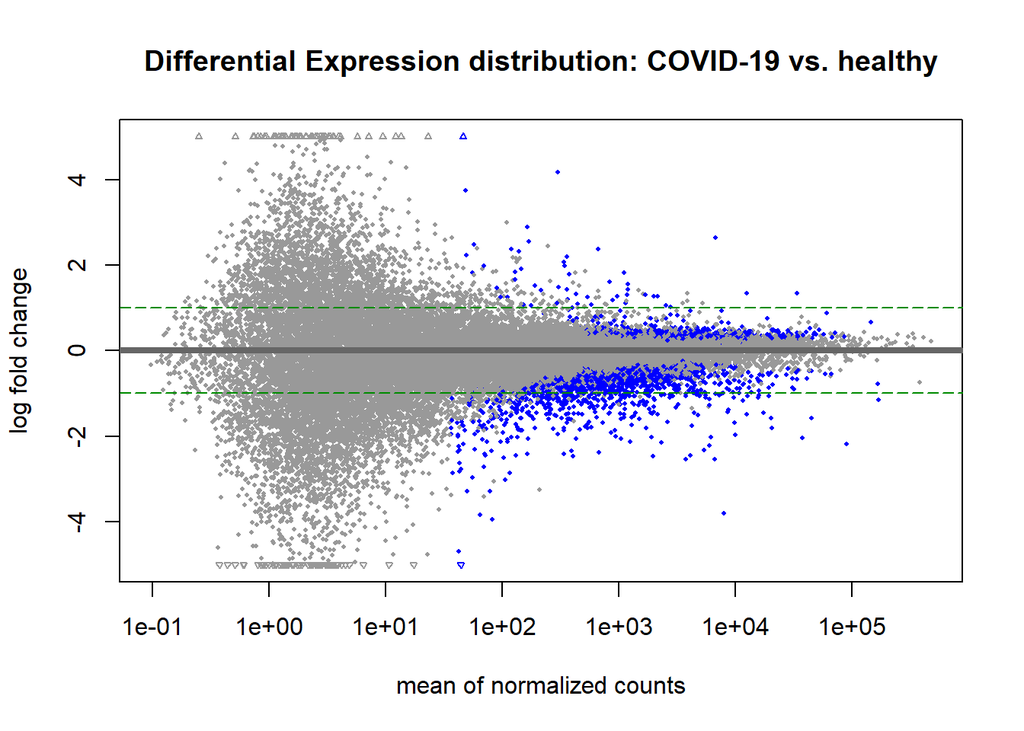

```r
plotMA_covid19 <- plotMA(res_covid, ylim=c(-5, 5),
       main="Differential Expression distribution: COVID-19 vs. healthy")
# Reference in log2FoldChange = 1
abline(h=c(-1, 1), col="green4", lty=5)
```

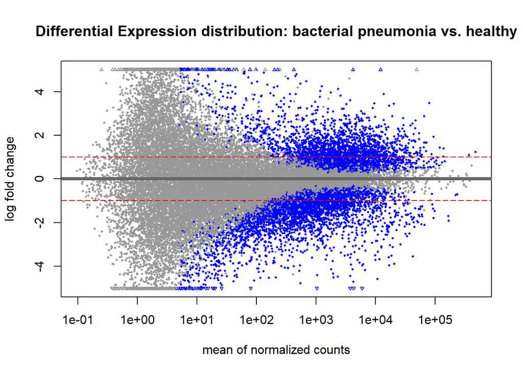

```r
plotMA_bact<- plotMA(res_bacterial, ylim=c(-5, 5),
       main="Differential Expression distribution: bacterial pneumonia vs. healthy")
# Reference in log2FoldChange = 1
abline(h=c(-1, 1), col= "red2", lty=5)
```

The **comparative differential expression analysis reveals distinct transcriptional landscapes between bacterial and viral etiologies**. While bacterial pneumonia induces a massive and symmetric inflammatory response characterized by a high number of significantly dysregulated genes, the COVID-19 signature appears more targeted. Notably, the COVID-19 profile exhibits a prominent cluster of down-regulated genes among high-abundance transcripts, suggesting a specific suppressive effect on host cellular processes.

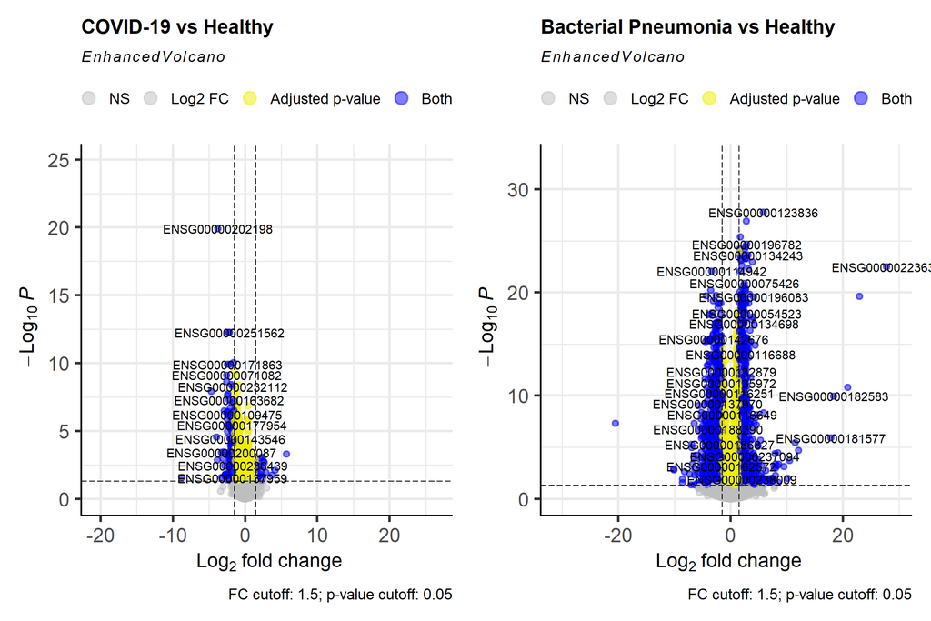

```r
# Volcano plot for COVID-19 vs Healthy
volcano_covid19 <- EnhancedVolcano(res_covid,
                lab = rownames(res_covid),
                x = 'log2FoldChange',
                y = 'padj',
                title = 'COVID-19 vs Healthy',
                pCutoff = 0.05,
                FCcutoff = 1.5,
                pointSize = 2.0,
                labSize = 4.0,
                col=c('grey', 'grey', 'yellow2', 'blue'),
                legendLabels=c('NS', 'Log2 FC', 'Adjusted p-value', 'Both'),
                caption = 'FC cutoff: 1.5; p-value cutoff: 0.05')

# Volcano plot for Bacterial vs Healthy
volcano_bacterial <- EnhancedVolcano(res_bacterial,
                lab = rownames(res_bacterial),
                x = 'log2FoldChange',
                y = 'padj',
                title = 'Bacterial Pneumonia vs Healthy',
                pCutoff = 0.05,
                FCcutoff = 1.5,
                pointSize = 2.0,
                labSize = 4.0,
                col=c('grey', 'grey', 'yellow2', 'blue'),
                legendLabels=c('NS', 'Log2 FC', 'Adjusted p-value', 'Both'),
                caption = 'FC cutoff: 1.5; p-value cutoff: 0.05')
volcano_covid19 | volcano_bacterial
```

To gain a overview of coincidences between the two cohorts we generate an upset plot. We use a threshold of foldchange 1.5 and alpha = 0.05 to represente Differential Expressed Genes.

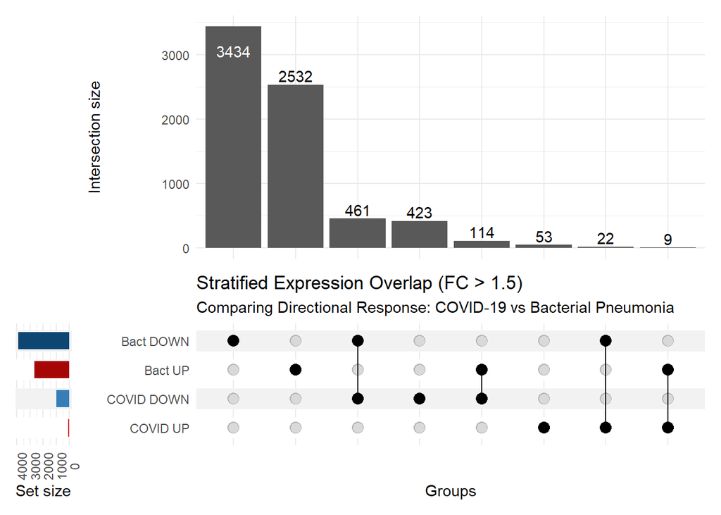

```r
# Threshold definition
lfc_threshold <- log2(1.5)

# Gene list
list_input <- list(
  `COVID UP`   = rownames(res_covid[which(res_covid$padj < 0.05 & res_covid$log2FoldChange > lfc_threshold), ]),
  `COVID DOWN` = rownames(res_covid[which(res_covid$padj < 0.05 & res_covid$log2FoldChange < -lfc_threshold), ]),
  `Bact UP`    = rownames(res_bacterial[which(res_bacterial$padj < 0.05 & res_bacterial$log2FoldChange > lfc_threshold), ]),
  `Bact DOWN`  = rownames(res_bacterial[which(res_bacterial$padj < 0.05 & res_bacterial$log2FoldChange < -lfc_threshold), ])
)

# Binary vector
all_genes <- unique(unlist(list_input))
upset_df <- data.frame(gene = all_genes)
for(set_name in names(list_input)) {
  upset_df[[set_name]] <- as.integer(upset_df$gene %in% list_input[[set_name]])
}

# colNames define the genes
sets_indices <- names(list_input)

#Upset plot
upset(
  upset_df,
  sets_indices, # Vector with colNames
  name = "Groups",
  width_ratio = 0.1,
  queries = list(
    upset_query(set = "COVID UP", fill = "#E41A1C"),
    upset_query(set = "Bact UP", fill = "#A60606"),
    upset_query(set = "COVID DOWN", fill = "#377EB8"),
    upset_query(set = "Bact DOWN", fill = "#0D4673")
  ),
  base_annotations = list(
    'Intersection size' = intersection_size(counts = TRUE)
  ),
  set_sizes = upset_set_size() + theme(axis.text.x = element_text(angle = 90))
) + labs(
    title = "Stratified Expression Overlap (FC > 1.5)",
    subtitle = "Comparing Directional Response: COVID-19 vs Bacterial Pneumonia"
)
```

These results identify a common molecular response to respiratory infections, highlighting **potential biomarkers for general lung inflammation and host defense mechanism**.

## 4.5 Functional enrichment analysis

We select the upregulated genes from COVID-19 and pneumonia patients (over healthy controls) to study the main mechanisms and physiological pathways activated under these conditions.

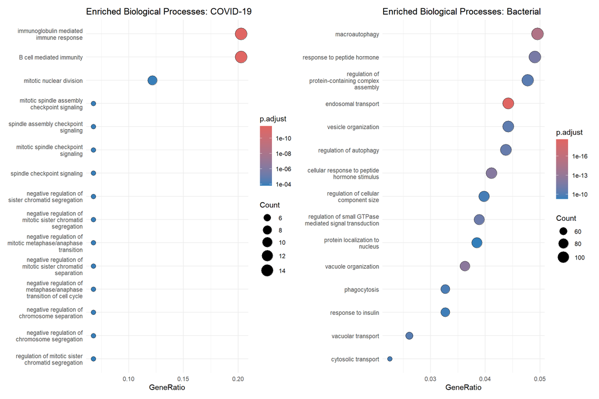

```r
covid_up <- list_input[["COVID UP"]]
bact_up  <- list_input[["Bact UP"]]

covid_up_clean <- as.character(covid_up)
bact_up_clean  <- as.character(bact_up)

enr_covid <- enrichGO(gene          = covid_up_clean,
                      OrgDb         = org.Hs.eg.db,
                      keyType       = 'ENSEMBL',
                      ont           = "BP",
                      pAdjustMethod = "BH",
                      pvalueCutoff  = 0.05,
                      qvalueCutoff  = 0.2)

enr_bact <- enrichGO(gene          = bact_up_clean,
                     OrgDb         = org.Hs.eg.db,
                     keyType       = 'ENSEMBL',
                     ont           = "BP",
                     pAdjustMethod = "BH",
                     pvalueCutoff  = 0.05,
                     qvalueCutoff  = 0.2)

#Visualization of the most enriched biological process in dotplot
enr_covid <- setReadable(enr_covid, OrgDb = org.Hs.eg.db, keyType="ENSEMBL") #Transformation of gene nomenclature
enr_bact  <- setReadable(enr_bact, OrgDb = org.Hs.eg.db, keyType="ENSEMBL")

# Plots
dot_covid <- dotplot(enr_covid, showCategory=15) +
  ggtitle("Enriched Biological Processes: COVID-19") +
  theme_minimal()

dot_bact <- dotplot(enr_bact, showCategory=15) +
  ggtitle("Enriched Biological Processes: Bacterial") +
  theme_minimal()

dot_covid | dot_bact
```

**Functional enrichment analysis reveals deep contrast between the two infectious etiologies despite their shared clinical presentation**. In COVID-19, the host response is predominantly characterized by immediate immune activation, specifically through immunoglobulin-mediated responses and B-cell-mediated cellular immunity. To a lesser extent, pathways related to cell division are also enriched, potentially reflecting lymphocyte proliferation.

In contrast, the bacterial infection signature is directly linked to **cellular structural and degradative processes, specifically autophagy, vesicle-mediated transport, and endocytosis**. These pathways likely represent the host’s attempt to internalize and degrade bacteria.

# 5. Discussion

The role of **Bioconductor in gene expression analysis** is invaluable for modern biomedical research. Currently, scientific standards require researchers to **deposit high-throughput sequencing data in public repositories such as the GEO (Gene Expression Omnibus)** Database. These datasets are typically available in both raw and processed formats, providing a transparent foundation for the scientific community.

For any bioinformatician the ability to interpret and re-analyze these studies is an essential skill. Public data serves as a powerful tool for comparative and complementary analysis, allowing for the validation of in-house findings against established benchmarks. Furthermore, leveraging the current state-of-the-art through existing experiments significantly optimizes research resources, reducing the need for redundant laboratory testing and accelerating the discovery of disease-specific molecular signatures.

In this study, among the top 15 enriched biological processes in COVID-19 and bacterial pneumonia, there is **minimal overlap between the two conditions**. This suggests that the molecular mechanisms driving the host’s defense are highly pathogen-specific, offering a clear transcriptomic basis for differential diagnosis.

# 6. Reproducibility statement

All raw transcriptomic data and corresponding clinical metadata analyzed in this study are publicly available through the **NCBI Gene Expression Omnibus (GEO) under the accession number GSE161731**. This ensures that the foundational evidence for our findings remains accessible for independent verification.

The complete analytical pipeline, including the **R Markdown (.Rmd) source code, pre-processing scripts, and high-resolution figures, is hosted on GitHub (https://github.com/lnungon/RNASeq-Differential-Expression-SARS-CoV-2)**. The repository is structured to allow for full computational replication of the results, from raw count processing to functional enrichment.

To ensure computational reproducibility, detailed information regarding the R environment, including package versions and system dependencies, is documented in the accompanying session_info.txt file.

[session information not shown]

# 7. Bibliography

Hicks, S. C., Townes, F. W., Teng, M., & Irizarry, R. A. (2018). Missing data and technical variability in single-cell RNA-sequencing experiments. Biostatistics, 19(4), 562–578. https://doi.org/10.1093/biostatistics/kxx053

McClain, M. T., Constantine, F. J., Henao, R., Liu, Y., Tsalik, E. L., Burke, T. W., Steinbrink, J. M., Petzold, E., Nicholson, B. P., Rolfe, R., Kraft, B. D., Kelly, M. S., Saban, D. R., Yu, C., Shen, X., Ko, E. M., Sempowski, G. D., Denny, T. N., Ginsburg, G. S., … Woods, C. W. (2021). Dysregulated transcriptional responses to SARS-CoV-2 in the periphery. Nature Communications, 12(1), 1079. https://doi.org/10.1038/s41467-021-21289-y

McClain, M. T., Constantine, F. J., Henao, R., Liu, Y., Tsalik, E. L., Burke, T. W., Steinbrink, J. M., Petzold, E., Nicholson, B. P., Rolfe, R., Kraft, B. D., Kelly, M. S., Saban, D. R., Yu, C., Shen, X., Ko, E. M., Sempowski, G. D., Denny, T. N., Ginsburg, G. S., … Woods, C. W. (2021). Dysregulated transcriptional responses to SARS-CoV-2 in the periphery. Nature Communications, 12(1), 1079. https://doi.org/10.1038/s41467-021-21289-y